# **CBA stock return exploration**

Jackson Zhou

## Introduction

In this report, I will perform exploratory data analysis on daily Commonwealth Bank of Australia (CBA) stock return return prices from 03/01/2012 to 11/9/2020, as outlined in the assignment specifications. This will involve:

- Plotting the prices and returns over time
- Calculating summary statistics for the price and return time series

## Importing packages

I will import any packages which might be useful for the analysis.

```r
library(tidyverse)  # Data manipulation
library(readxl)     # Load Excel files
library(data.table) # Shift vectors
library(e1071)      # Skewness and kurtosis functions
```

## Loading in and cleaning the data

To start, I will load in the CBA stock price data from the relevant cell range in the provided Excel file. After this, I will generate the the time series for the returns, as specified by the following formula:
$$y_t=\log\frac{P_t}{P_{t-1}}$$

```r
stock.data <- read_excel("Price History_Commonwealth bank.xlsx", sheet = "Sheet 1", range = "A12:B2210") %>%
  rename("date" = "Exchange Date",
         "price" = "Close") %>%
  mutate(return = round(log(price/shift(price, n = 1)), 5))
```

## Plotting the data

### Plotting the stock prices

Luckily, the `date` column has the correct data type, so I won’t need to do any further work to get the plotting to work correctly.

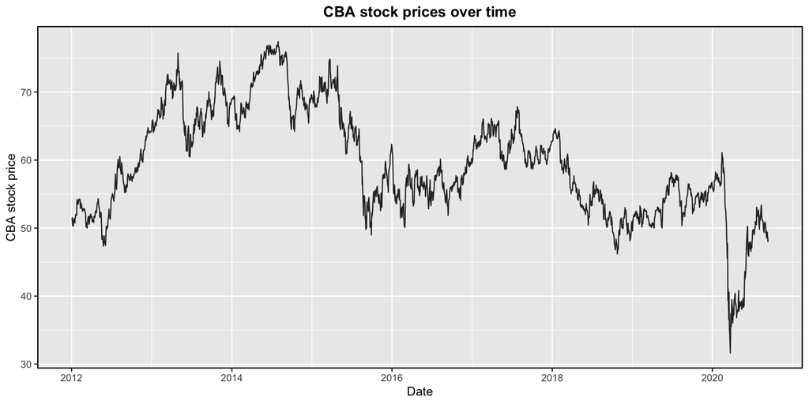

```r
stock.data %>%
  ggplot(mapping = aes(x = date, y = price)) +
  geom_line(colour = "#303030") +
  labs(title = "CBA stock prices over time",
       x = "Date",
       y = "CBA stock price") +
  theme(plot.title = element_text(face = "bold", hjust = 0.5),
        panel.border = element_rect(colour = "black", fill = NA, size = 1))
```

Visualising the distribution of the stock prices using a histogram:

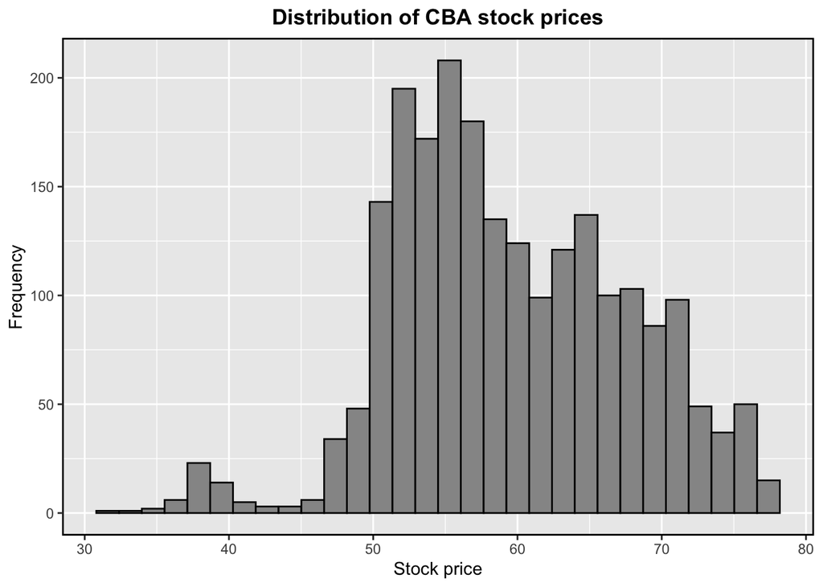

```r
stock.data %>%
  ggplot(mapping = aes(x = price)) +
  geom_histogram(bins = 30, colour = "black", fill = "#969696") +
  labs(title = "Distribution of CBA stock prices",
       x = "Stock price",
       y = "Frequency") +
  theme(plot.title = element_text(face = "bold", hjust = 0.5),
        panel.border = element_rect(colour = "black", fill = NA, size = 1))
```

### Plotting the stock returns

Using similar code from the previous section:

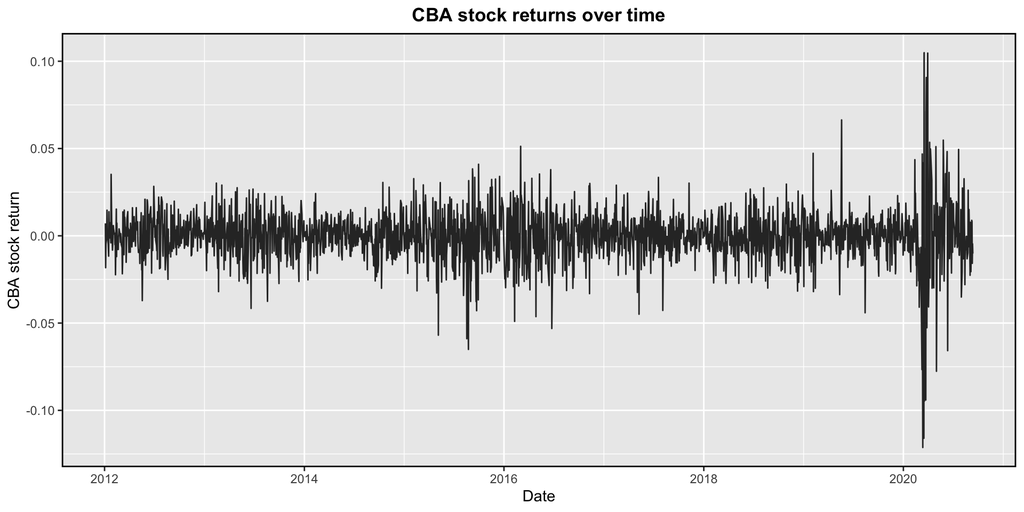

```r
stock.data %>%
  ggplot(mapping = aes(x = date, y = return)) +
  geom_line(colour = "#303030") +
  labs(title = "CBA stock returns over time",
       x = "Date",
       y = "CBA stock return") +
  theme(plot.title = element_text(face = "bold", hjust = 0.5),
        panel.border = element_rect(colour = "black", fill = NA, size = 1))
```

Visualising the distribution of the stock returns using a histogram:

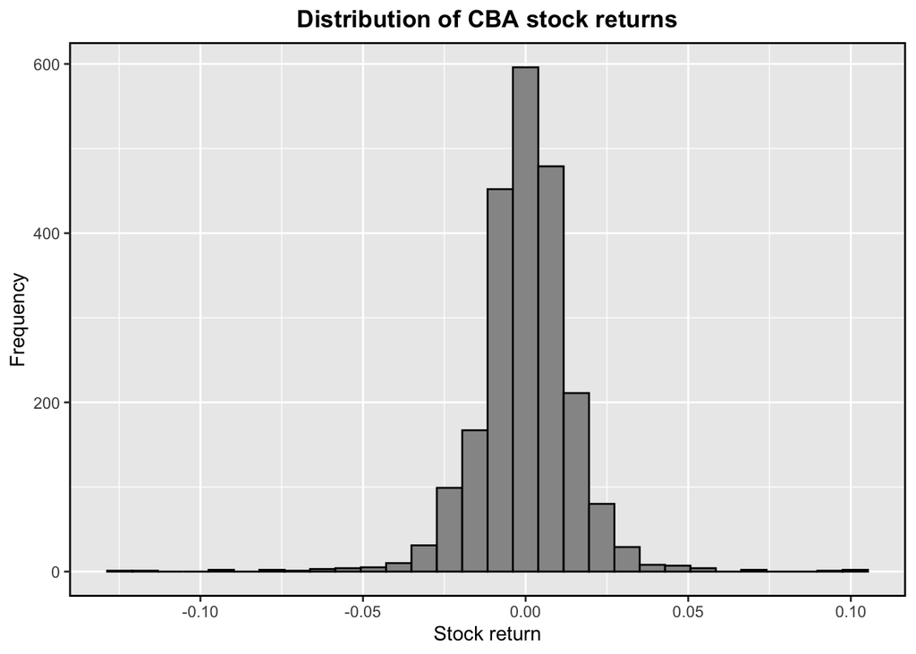

```r
stock.data %>%
  ggplot(mapping = aes(x = return)) +
  geom_histogram(bins = 30, colour = "black", fill = "#969696") +
  labs(title = "Distribution of CBA stock returns",
       x = "Stock return",
       y = "Frequency") +
  theme(plot.title = element_text(face = "bold", hjust = 0.5),
        panel.border = element_rect(colour = "black", fill = NA, size = 1))
```

## Calculating the summary statistics

Calculating basic summary statistics for the stock prices and returns:

```r
stock.data %>%
  select(all_of(c("price", "return"))) %>%
  summary()
```

```
##      price           return
##  Min.   :31.62   Min.   :-0.1212700
##  1st Qu.:53.62   1st Qu.:-0.0073400
##  Median :58.12   Median : 0.0002300
##  Mean   :59.42   Mean   :-0.0000298
##  3rd Qu.:65.44   3rd Qu.: 0.0079000
##  Max.   :77.43   Max.   : 0.1048900
##                  NA's   :1
```

Calculating skewness and kurtosis for the stock prices and returns:

```r
cat("For the CBA stock prices, the skewness is ",
    round(skewness(stock.data$price), 5),
    " and the kurtosis is ",
    round(kurtosis(stock.data$price), 5),
    "\nFor the CBA stock returns, the skewness is ",
    round(skewness(stock.data$return, na.rm = TRUE), 5),
    " and the kurtosis is ",
    round(kurtosis(stock.data$return, na.rm = TRUE), 5), sep = "")
```

```
## For the CBA stock prices, the skewness is 0.00625 and the kurtosis is -0.16359
## For the CBA stock returns, the skewness is -0.47977 and the kurtosis is 9.42731
```